# Code4Sac: 311 Service Call Data Analysis

Author: Walter Yu  
Organization: Code for Sacramento

# Introduction

Code for Sacramento is develop a neighborhood portal application; as a result, this notebook evaluates the City of Sacramento 311 service call dataset for insights and trends which may be helpful in developing useful features. This notebook will focus on an initial analysis and identifying potential issues related to users and their neighborhoods.

Conjecture:

Per discussion with City of Sacramento staff, 311 service calls are a relatively stable source for identify potential issues/needs of neighborhoods. Included are time and location data which will be useful for identifying trends.

# Findings:

1. Conventional statistical and machine learning methods were not a good fit for analyzing service call data due to its highly categorial nature; almost all variables were categorical with exception of time/location data.
2. Exploratory data analysis and logistic regression were used to confirm this finding; spatial analysis was used to yield better results.
3. Clustering and density plots were developed in the GeoDa software application to identify natural concentrations of service calls by zipcode.

Methodology:

1. Exploratory data analysis (EDA) and model fits showed that spatial and temporal analysis would be more appropriate methods of analysis.
2. As a result, spatial analysis with R and GeoDa were used to identify trends.
3. Findings are documented within the notebook; additional analysis was completed in GeoDa.

Dataset:

311 service call dataset from City of Sacramento; summary statistics for the full and partial datasets are listed below. The data is available in geospatial, tabular or API format; the tabular format is used for this analysis to identify important neighborhoods and trends which are relevant to developing the application.

City of Sacramento 311 Service Call Dataset: https://data.cityofsacramento.org/datasets/08794a6695b3483f889e9bef122517e9_0

Citations:  
1. HES CSCI E-63c: https://www.extension.harvard.edu/course-catalog/courses/elements-of-data-science-and-statistical-learning-with-r/15123  
2. ISLR Textbook: https://www-bcf.usc.edu/~gareth/ISL/  
3. ESLR Textbook: https://web.stanford.edu/~hastie/ElemStatLearn/

Notes:  
1. All sources are cited accordingly.  
2. Source dataset is ~1.2M rows, so not included in this repository.  
3. As a result, please review attached HTML file for analysis/findings.

# Part 1A - Summary Statistics

References:  
1. HES CSCI-E63c Midterm, HW9, HW10, HW11 code  
2. ISLR p.28; categorical variables

Steps:  
1. Import data, evaluate dimensions with dim() and str() functions  
2. Subset first 5k rows to reduce runtime  
3. Subset columns to only include relevant data (time, location, type)  
4. Verify subset with summary statistics; dim, str and summary functions

Observations:  
1. Dataset consists of categorical variables and time/location data  
2. Most categorical have multiple levels; some have many (e.g. category level)  
3. Time data recorded as timestamps; locations in lat/long coordinates  
4. Call category, time and location data appear most relevant  
5. As a result, those variables were extracted as a subset

Data Manipulation:  
1. Original dataset = ~1.2M rows x 27 columns  
2. Reduced dataset = 5k rows x 27 columns  
3. Test dataset may be extracted from full dataset  
4. Convert categorical variables as factors to facilitate logistic regression  
5. Factors will be converted to numeric values to facilitate analysis

```r
# import data
train_data <- read.table(
  '311_Calls_OSC_View.csv',
  sep=',',
  header=TRUE,
  quote='',
  strip.white=TRUE,
  na.strings='?'
)

# extract first 5k rows for smaller training dataset:
train_reduced = train_data[1:5000,]
write.csv(train_reduced, file = "train_5k.csv")

# verify dim:
dim(train_reduced)
```

```
## [1] 5000   27
```

Data Attributes:

$ X : num  
$ Y : num  
$ OBJECTID : int  
$ ReferenceNumber : Factor w/ 1130759 levels  
$ CategoryHierarchy : Factor w/ 437 levels  
$ CategoryLevel1 : Factor w/ 18 levels  
$ CategoryLevel2 : Factor w/ 48 levels  
$ CategoryLevel3 : Factor w/ 10 levels  
$ CategoryLevel4 : logi  
$ CategoryLevel5 : logi  
$ CategoryName : Factor w/ 286 levels  
$ CouncilDistrictNumber: int  
$ SourceLevel1 : Factor w/ 5 levels  
$ Neighborhood : Factor w/ 130 levels  
$ DateCreated : Factor w/ 1118207 levels  
$ DateUpdated : Factor w/ 927449 levels  
$ DateClosed : Factor w/ 772674 levels  
$ StatusType : Factor w/ 14 levels  
$ SystemId : int  
$ ServiceLevelName : Factor w/ 34 levels  
$ Latitude : num  
$ Longitude : num  
$ XCoord : num  
$ YCoord : num  
$ CrossStreet : Factor w/ 11685 levels  
$ GlobalID : Factor w/ 1225340 levels  
$ ZIP : Factor w/ 66 levels

```r
# reduce to smaller sample size for relevant data:
train_col = train_reduced[, c(
  # "X",
  # "Y",
  "CategoryHierarchy",
  "CategoryName",
  "CategoryLevel1",
  "CategoryLevel2",
  "CategoryLevel3",
  "CouncilDistrictNumber",
  "SourceLevel1",
  "Neighborhood",
  "DateCreated",
  "DateUpdated",
  "DateClosed",
  "StatusType",
  "ServiceLevelName",
  "Latitude",
  "Longitude",
  "XCoord",
  "YCoord",
  "ZIP"
)]

# verify dim and drop NA; train_data:
# which(is.na(train_col))
# dim(train_col)
# train_col = na.omit(train_col)
# dim(train_col)

# EDA output; train_data:
# summary(train_col)
dim(train_col)
```

```
## [1] 5000   18
```

```r
str(train_col)
```

```
## 'data.frame':    5000 obs. of  18 variables:
##  $ CategoryHierarchy    : Factor w/ 437 levels ":",": Code Enforcement",..: 342 340 326 318 323 326 339 363 326 71 ...
##  $ CategoryName         : Factor w/ 286 levels "","911 Transfer",..: 91 137 109 91 91 109 91 142 109 183 ...
##  $ CategoryLevel1       : Factor w/ 18 levels "","Animal care",..: 14 14 14 14 14 14 14 14 14 3 ...
##  $ CategoryLevel2       : Factor w/ 48 levels "","Animal Cruelty (597)",..: 28 26 1 15 18 1 26 39 1 17 ...
##  $ CategoryLevel3       : Factor w/ 10 levels "","Aggressive",..: 1 1 1 1 1 1 1 4 1 1 ...
##  $ CouncilDistrictNumber: int  3 7 8 1 4 5 3 5 8 3 ...
##  $ SourceLevel1         : Factor w/ 5 levels "","Email","Mobile App",..: 4 4 4 4 4 5 4 5 4 4 ...
##  $ Neighborhood         : Factor w/ 130 levels "","Airport","Alhambra Triangle",..: 102 85 115 67 56 44 102 73 115 31 ...
##  $ DateCreated          : Factor w/ 1118207 levels "2016-04-30T16:05:44.000Z",..: 2988 2989 2990 2991 2992 2993 2994 2995 2996 2997 ...
##  $ DateUpdated          : Factor w/ 927449 levels "2016-04-30T16:46:53.000Z",..: 238837 146545 284898 238837 146543 241794 232773 238864 284900 295 ...
##  $ DateClosed           : Factor w/ 772674 levels "","2016-05-30T18:53:03.000Z",..: 218275 136981 261213 218275 136981 221113 212237 218302 261213 1 ...
##  $ StatusType           : Factor w/ 14 levels "Cancellation Completed",..: 4 3 4 4 3 4 4 4 4 8 ...
##  $ ServiceLevelName     : Factor w/ 34 levels "","1 Hour-All Holidays-24/7",..: 13 13 1 1 1 1 13 1 1 29 ...
##  $ Latitude             : num  38.6 38.5 38.4 38.6 38.5 ...
##  $ Longitude            : num  -121 -122 -121 -122 -122 ...
##  $ XCoord               : num  6706636 6692383 6730272 6700552 6697903 ...
##  $ YCoord               : num  1988045 1940692 1925199 1993886 1953896 ...
##  $ ZIP                  : Factor w/ 66 levels "","00000","11111",..: 53 51 32 54 42 42 53 40 43 36 ...
```

```r
# Encode categorial variables as factors:
# https://stats.idre.ucla.edu/r/modules/coding-for-categorical-variables-in-regression-models/

# Selected columns for relevant data:
# "CategoryHierarchy",
# "CategoryName",
# "CategoryLevel1",
# "CategoryLevel2",
# "CategoryLevel3",
# "CouncilDistrictNumber",
# "SourceLevel1",
# "Neighborhood",
# "StatusType",
# "ServiceLevelName",
# "ZIP"

train_col$cat_heir.f <- factor(train_col$CategoryHierarchy)
is.factor(train_col$cat_heir.f)
```

```
## [1] TRUE
```

```r
train_col$cat_name.f <- factor(train_col$CategoryName)
is.factor(train_col$cat_name.f)
```

```
## [1] TRUE
```

```r
train_col$cat_1.f <- factor(train_col$CategoryLevel1)
is.factor(train_col$cat_1.f)
```

```
## [1] TRUE
```

```r
train_col$cat_2.f <- factor(train_col$CategoryLevel2)
is.factor(train_col$cat_2.f)
```

```
## [1] TRUE
```

```r
train_col$cat_3.f <- factor(train_col$CategoryLevel3)
is.factor(train_col$cat_3.f)
```

```
## [1] TRUE
```

```r
train_col$district.f <- factor(train_col$CouncilDistrictNumber)
is.factor(train_col$district.f)
```

```
## [1] TRUE
```

```r
train_col$source.f <- factor(train_col$SourceLevel1)
is.factor(train_col$source.f)
```

```
## [1] TRUE
```

```r
train_col$neighborhood.f <- factor(train_col$Neighborhood)
is.factor(train_col$neighborhood.f)
```

```
## [1] TRUE
```

```r
train_col$status.f <- factor(train_col$StatusType)
is.factor(train_col$status.f)
```

```
## [1] TRUE
```

```r
train_col$service.f <- factor(train_col$ServiceLevelName)
is.factor(train_col$service.f)
```

```
## [1] TRUE
```

```r
train_col$zip.f <- factor(train_col$ZIP)
is.factor(train_col$zip.f)
```

```
## [1] TRUE
```

```r
# convert into numeric values:
# train_col_numeric = train_col
# train_col_numeric %>% mutate_if(is.factor, as.numeric)

# convert with lapply function:
# https://stackoverflow.com/questions/47922184/convert-categorical-variables-to-numeric-in-r

train_col_numeric = train_col
i <- sapply(train_col_numeric, is.factor)
train_col_numeric[i] <- lapply(train_col_numeric[i], as.numeric)

# verify columns as numeric:
# str(train_col_numeric)
# head(train_col_numeric, 5)

# summary statistics for numeric values
# summary(train_col_numeric)
dim(train_col_numeric)
```

```
## [1] 5000   29
```

```r
str(train_col_numeric)
```

```
## 'data.frame':    5000 obs. of  29 variables:
##  $ CategoryHierarchy    : num  342 340 326 318 323 326 339 363 326 71 ...
##  $ CategoryName         : num  91 137 109 91 91 109 91 142 109 183 ...
##  $ CategoryLevel1       : num  14 14 14 14 14 14 14 14 14 3 ...
##  $ CategoryLevel2       : num  28 26 1 15 18 1 26 39 1 17 ...
##  $ CategoryLevel3       : num  1 1 1 1 1 1 1 4 1 1 ...
##  $ CouncilDistrictNumber: int  3 7 8 1 4 5 3 5 8 3 ...
##  $ SourceLevel1         : num  4 4 4 4 4 5 4 5 4 4 ...
##  $ Neighborhood         : num  102 85 115 67 56 44 102 73 115 31 ...
##  $ DateCreated          : num  2988 2989 2990 2991 2992 ...
##  $ DateUpdated          : num  238837 146545 284898 238837 146543 ...
##  $ DateClosed           : num  218275 136981 261213 218275 136981 ...
##  $ StatusType           : num  4 3 4 4 3 4 4 4 4 8 ...
##  $ ServiceLevelName     : num  13 13 1 1 1 1 13 1 1 29 ...
##  $ Latitude             : num  38.6 38.5 38.4 38.6 38.5 ...
##  $ Longitude            : num  -121 -122 -121 -122 -122 ...
##  $ XCoord               : num  6706636 6692383 6730272 6700552 6697903 ...
##  $ YCoord               : num  1988045 1940692 1925199 1993886 1953896 ...
##  $ ZIP                  : num  53 51 32 54 42 42 53 40 43 36 ...
##  $ cat_heir.f           : num  143 141 132 124 129 132 140 161 132 37 ...
##  $ cat_name.f           : num  41 65 51 41 41 51 41 68 51 85 ...
##  $ cat_1.f              : num  13 13 13 13 13 13 13 13 13 2 ...
##  $ cat_2.f              : num  21 19 1 11 14 1 19 29 1 13 ...
##  $ cat_3.f              : num  1 1 1 1 1 1 1 4 1 1 ...
##  $ district.f           : num  3 7 8 1 4 5 3 5 8 3 ...
##  $ source.f             : num  3 3 3 3 3 4 3 4 3 3 ...
##  $ neighborhood.f       : num  88 73 101 56 45 37 88 62 101 28 ...
##  $ status.f             : num  3 2 3 3 2 3 3 3 3 4 ...
##  $ service.f            : num  12 12 1 1 1 1 12 1 1 22 ...
##  $ zip.f                : num  25 23 7 26 17 17 25 15 18 11 ...
```

References:  
1. HES CSCI-E63c HW2 code  
2. https://en.wikipedia.org/wiki/Pearson_correlation_coefficient  
3. https://en.wikipedia.org/wiki/Spearman%27s_rank_correlation_coefficient

Steps:  
1. Calculate correlation and create correlation plot  
2. Plots for Pearson and Spearman correlation methods  
3. Document observations below

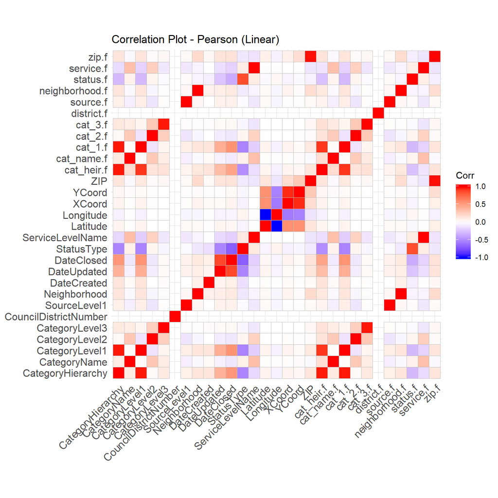

```r
# create correlation plot:
corr <- round(cor(train_col_numeric, method="pearson", use="everything"), 4)
ggcorrplot(corr, title="Correlation Plot - Pearson (Linear)")
```

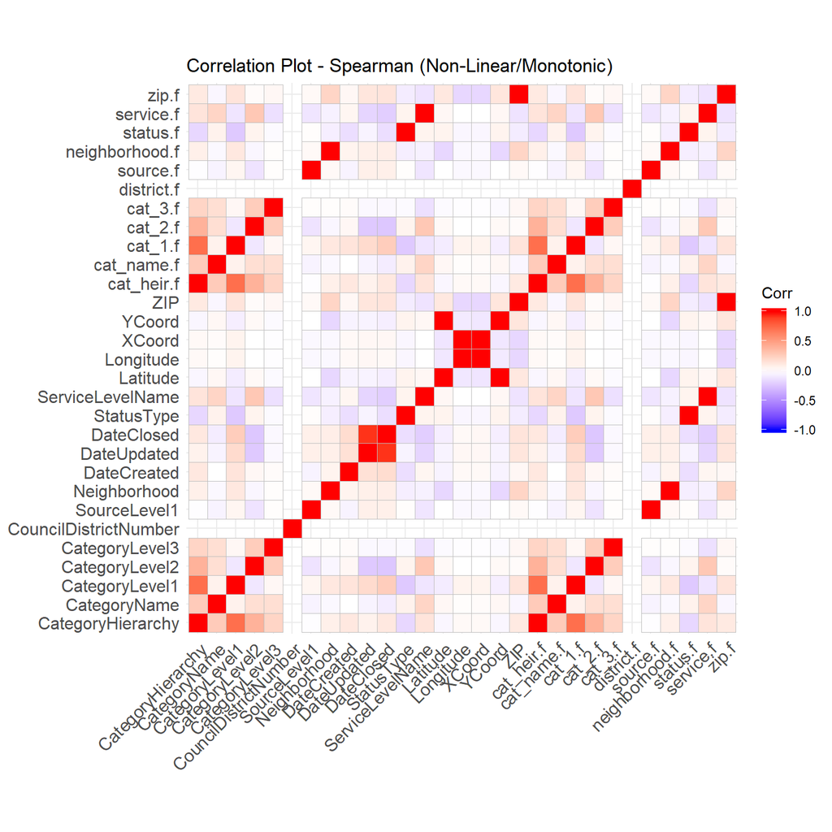

```r
# create correlation plot:
corr <- round(cor(train_col_numeric, method="spearman", use="everything"), 4)
ggcorrplot(corr, title="Correlation Plot - Spearman (Non-Linear/Monotonic)")
```

References:  
1. HES CSCI-E63c Midterm, HW5 code  
2. ISLR p.67; p-value

Observations:  
1. Categorical variables provide limited use for histogram plots since they are intended for continuous/numeric variables  
2. However, call frequency by district number histogram showed distribution while the other plots/variables did not convert well or translate into coherent plots

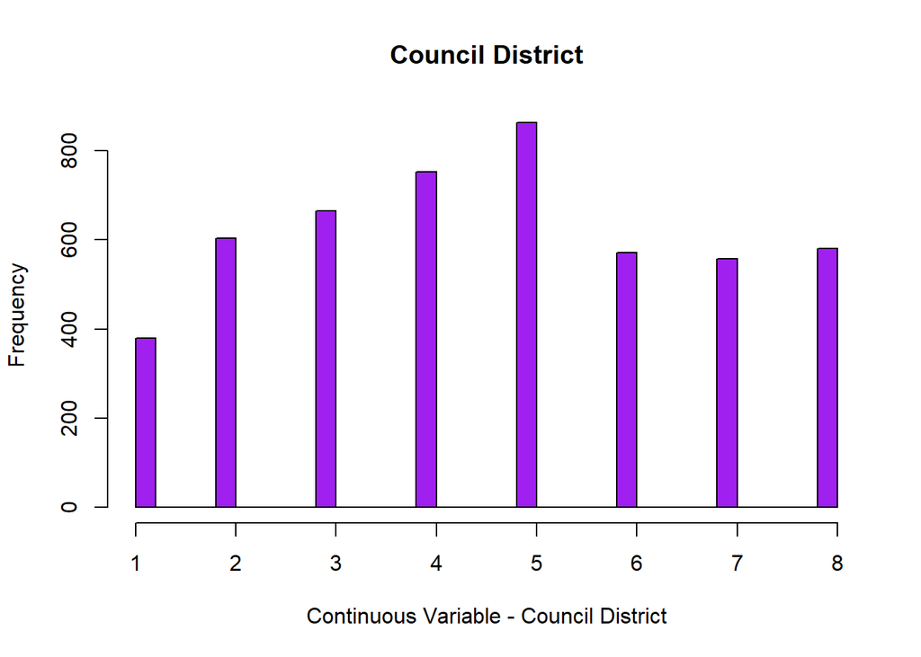

```r
# Create historgram to evaluate distribution:
hist(
  train_col_numeric$district.f,
  main='Council District',
  col='purple',
  xlab='Continuous Variable - Council District',
  breaks=30
)
```

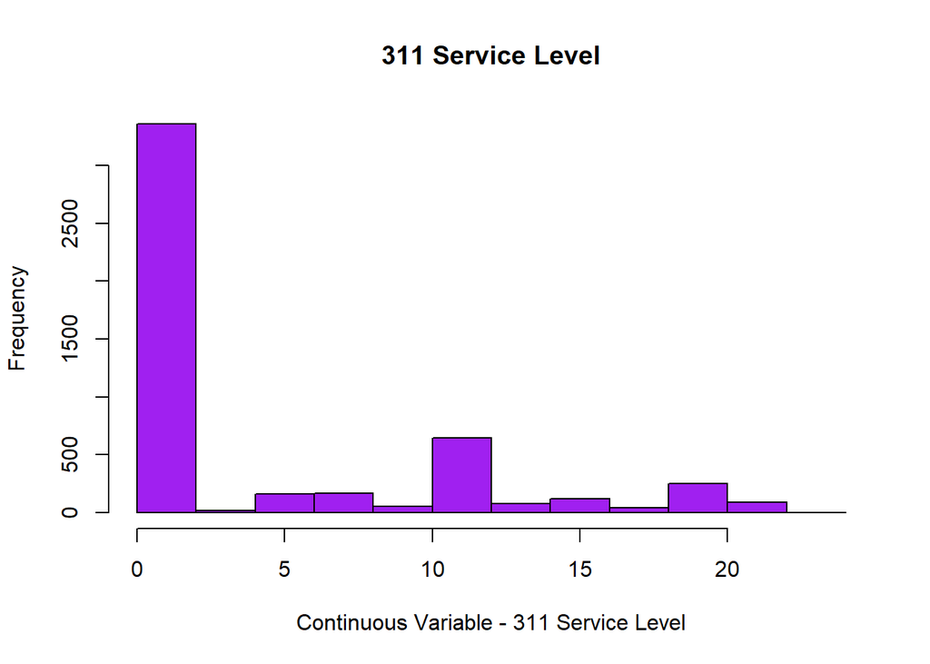

```r
hist(
  train_col_numeric$service.f,
  main='311 Service Level',
  col='purple',
  xlab='Continuous Variable - 311 Service Level',
  breaks=10
)
```

References:  
1. Spatial plot: https://rspatial.org/rosu/Chapter5.html  
2. R Spatial Textbook: https://rspatial.org/rosu/ROSU.pdf

Steps:  
1. Develop spatial analysis plots below to identify trends

Observations:  
1. Since variables do not appear to have strong correlations and EDA shows that most variables only have an association for individual values/levels  
2. As a result, explore other analytical methods to identify trends; primarily, time series and geospatial analysis

```r
# verify data dimensions/columns:
# str(train_col)
# dim(train_col)

# plot service call data on world map:
plot(train_col[,15:14], cex=0.5, col='red')

## Checking rgeos availability: TRUE
data(wrld_simpl)
plot(wrld_simpl, add=TRUE)
```

[output not shown]

```r
# plot service call data on state map:
counties <- sp_data('counties')
plot(counties)
points(train_col[,c('Longitude', 'Latitude')], col='blue', pch=20)
```

[output not shown]

```r
# load rspatial if needed:
if (!require("rspatial")) devtools::install_github('rspatial/rspatial')
```

```r
library(rspatial)

# test plot by county:
# yolo <- counties[counties$NAME == 'Yolo', ]
# plot(yolo, col='light gray', border='gray')

# organize service calls by category type:
tb <- sort(table(train_col$CategoryLevel1))[-1]
tb
```

```
##
##                          Zoning                        Non-City
##                               2                               5
## Housing and Dangerous Buildings                   DOU - Billing
##                               6                               9
##                          Drains                  Urban Forestry
##                              21                              40
##                           Other            Streets and Lighting
##                              43                              43
##                Code Enforcement                           Parks
##                              48                              59
##                           Sewer                      Facilities
##                              68                              90
##             Building / Planning                         Parking
##                              96                             110
##                     Animal care                           Water
##                             202                             220
##                     Solid Waste
##                            3938
```

```r
# duplicate training data for manipulation:
train_xy <- train_col

# extract lag/long and convert to coordinates:
# xy <- train_xy[,15:14]
# coordinates(xy)

# extract lag/long and convert to coordinates:
# xy <- train_xy[,c('XCoord', 'YCoord')]
xy <- train_xy[,c('Longitude', 'Latitude')]
dim(xy)
```

```
## [1] 5000    2
```

```r
# remove duplications and verify dimensions:
xy <- unique(xy)
dim(xy)
```

```
## [1] 3969    2
```

```r
# calculate mean center
mc <- apply(xy, 2, mean)
# calculate standard distance
sd <- sqrt(sum((xy[,1] - mc[1])^2 + (xy[,2] - mc[2])^2) / nrow(xy))
```

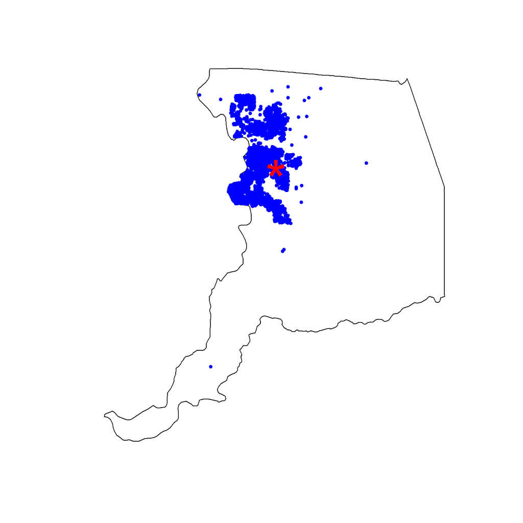

```r
# plot county:
counties <- sp_data('counties')
county <- counties[counties$NAME == 'Sacramento', ]
plot(county)

# plot points:
points(train_xy[,c('Longitude', 'Latitude')], col='blue', pch=20)
# points(xy, cex=.5)

points(cbind(mc[1], mc[2]), pch='*', col='red', cex=5)
# make a circle
bearing <- 1:360 * pi/180
cx <- mc[1] + sd * cos(bearing)
cy <- mc[2] + sd * sin(bearing)
circle <- cbind(cx, cy)
lines(circle, col='red', lwd=2)
```

References:  
1. HES CSCI-E63c Lecture 1, 3 notes; chi-squared test  
2. ISLR p.67; p-value and significance

Steps:  
1. Calculate chi-squared test for categorical variables  
2. Evaluate/analyze results  
3. Document observations below

```r
# Chi-Squared test for continuous variables:
t.test(
  as.numeric(train_col$neighborhood.f),
  train_data$service.f
)

# Chi-Squared test for categorical variables:
chisq.test(
  table(
    train_col$neighborhood.f,
    train_col$cat_1.f
  )
)
```

[output not shown]

References:  
1. HES CSCI-E63c Midterm, HW6; PCA model  
2. ISLR p.230; PCA components  
3. ISLR p.233; PCA components

Steps:  
1. Verify/prepare data for PCA plots; use dummy variables to setup factors  
2. Scale/fit data for PCA plots; plot for top contributors to variance  
3. Evaluate top contributors to variance  
4. Plot variance by first several PCA

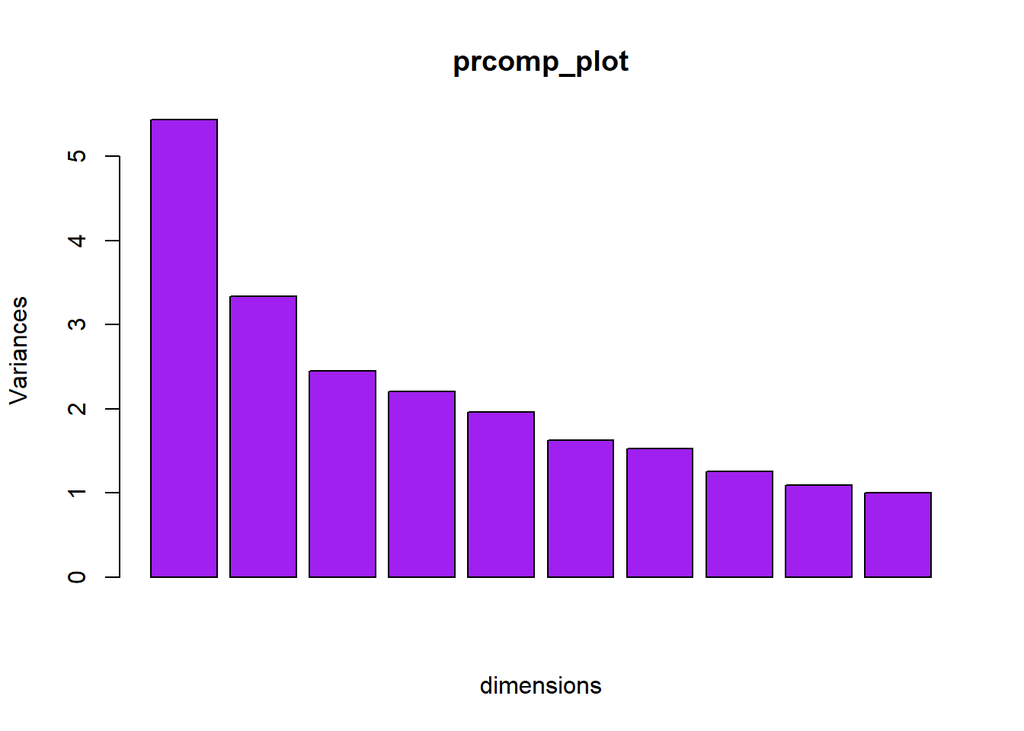

```r
# train_scaled = train_data %>% mutate_if(is.numeric, scale)
# train_dummy = model.matrix(noyes ~., train_scaled)[,-1]

# Scale/dummy data prior to plot:
# train_numeric = as.numeric(train_col$zip.f)
# train_scaled = train_numeric %>% mutate_if(is.numeric, scale)
# train_dummy = model.matrix(noyes ~., train_scaled)[,-1]

# Scale/dummy data prior to plot:
train_scaled = train_col_numeric %>% mutate_if(is.numeric, scale)
train_dummy = model.matrix(Neighborhood ~., train_scaled)[,-1]

# prepare PCA components for plot:
prcomp_plot = prcomp(train_dummy)
plot(
  prcomp_plot,
  xlab='dimensions',
  col='purple'
)
```

```r
# calculate top five PCA components:
sort(abs(prcomp_plot$rotation[,1]), decreasing=TRUE)[1]
```

```
## CategoryLevel1
##      0.3884004
```

```r
sort(abs(prcomp_plot$rotation[,2]), decreasing=TRUE)[1]
```

```
## CategoryName
##    0.4030306
```

```r
sort(abs(prcomp_plot$rotation[,3]), decreasing=TRUE)[1]
```

```
## CouncilDistrictNumber
##             0.4911013
```

```r
sort(abs(prcomp_plot$rotation[,4]), decreasing=TRUE)[1]
```

```
##   cat_3.f
## 0.5074967
```

```r
sort(abs(prcomp_plot$rotation[,5]), decreasing=TRUE)[1]
```

```
## SourceLevel1
##    0.6443328
```

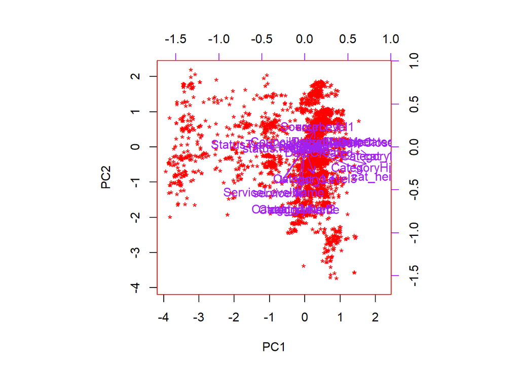

```r
# create biplot of PCA components:
biplot(
  prcomp_plot,
  pc.biplot=TRUE,
  xlabs=rep('*', dim(prcomp_plot$x)[1]),
  col=c('red','purple')
)
```

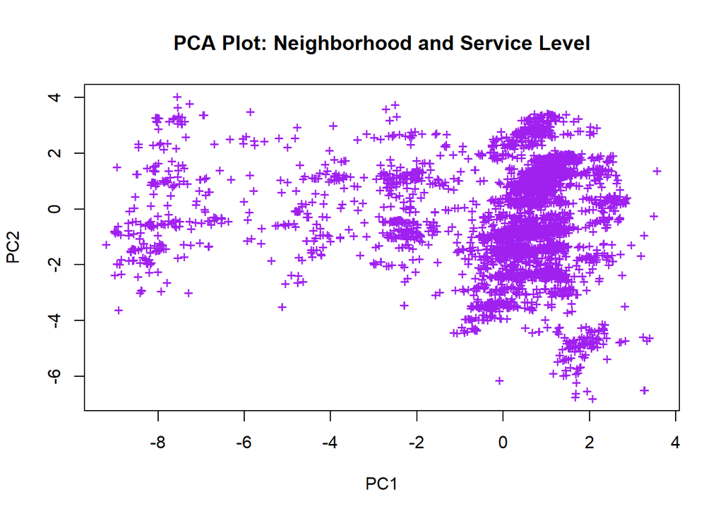

```r
# create PCA plot:
plot(
  prcomp_plot$x[,1:2],
  main='PCA Plot: Neighborhood and Service Level',
  col=c(ifelse(train_col_numeric$Neighborhood== '>=10', 'red', 'purple')),
  cex=1.0,
  pch=ifelse(train_col_numeric$ServiceLevelName== '>=1', '*', '+')
)
```

References:  
1. ISLR p.67; p-value and significance  
2. ISLR p.286; logistic regression  
3. ISLR p.291; logistic regression usage

Steps:  
1. Fit logistic regression model for predictor variables  
2. Evaluate/compare results of each variable  
3. Specifically, evaluate p-values of logistic regression output  
4. Evaluate results for association between predictor/outcome

Observations:  
1. Most variables did not have low p-values, indicating poor model fit  
2. However, some variables did show significance  
3. Specifiically, some neighborhoods show relationship with particular call categories

```r
# LR model fit:

glm_train = glm(
  CategoryLevel1~neighborhood.f,
  data=train_col,
  family=binomial
)
summary(glm_train)
```

```
##
## Call:
## glm(formula = CategoryLevel1 ~ neighborhood.f, family = binomial,
##     data = train_col)
##
## Deviance Residuals:
##      Min        1Q    Median        3Q       Max
## -3.10232   0.00005   0.18273   0.24808   1.17741
##
## Coefficients:
##                                                      Estimate Std. Error
## (Intercept)                                         1.771e+00  3.825e-01
## neighborhood.fAirport                               4.806e-01  8.360e-01
## neighborhood.fAlhambra Triangle                     1.880e+01  8.865e+03
## neighborhood.fAlkali Flat                           1.880e+01  5.910e+03
## neighborhood.fAmerican River Parkway                1.880e+01  1.773e+04
## neighborhood.fArden Fair                            1.880e+01  1.773e+04
## neighborhood.fAvondale                              6.272e-01  8.317e-01
## neighborhood.fBen Ali                               1.225e+00  1.094e+00
## neighborhood.fBoulevard Park                        1.225e+00  1.094e+00
## neighborhood.fBrentwood                             1.225e+00  1.094e+00
## neighborhood.fCampus Commons                        1.880e+01  4.179e+03
## neighborhood.fCannon Industrial Park               -1.771e+00  1.465e+00
## neighborhood.fCarleton Tract                        1.880e+01  4.918e+03
## neighborhood.fCentral Oak Park                      1.274e+00  5.965e-01
## neighborhood.fCollege Town                          1.880e+01  1.254e+04
## neighborhood.fCollege/Glen                          1.880e+01  1.839e+03
## neighborhood.fColonial Heights                      1.880e+01  3.292e+03
## neighborhood.fColonial Manor                        9.034e-01  8.251e-01
## neighborhood.fColonial Village                      1.880e+01  3.041e+03
## neighborhood.fCreekside                             3.694e-01  8.397e-01
## neighborhood.fCSUS                                  1.880e+01  1.024e+04
## neighborhood.fCurtis Park                           2.939e+00  1.075e+00
## neighborhood.fDel Paso Heights                      1.297e+00  8.183e-01
## neighborhood.fDel Paso Park                         1.880e+01  1.024e+04
## neighborhood.fDos Rios Triangle                     1.880e+01  1.254e+04
## neighborhood.fDowntown                             -1.274e+00  4.067e-01
## neighborhood.fEast Del Paso Heights                 1.880e+01  2.673e+03
## neighborhood.fEast Sacramento                       2.314e+00  5.913e-01
## neighborhood.fElmhurst                              1.880e+01  2.955e+03
```

[output cut: 197 more lines]

```
## neighborhood.fWills Acres                            0.004 0.996835
## neighborhood.fWoodbine                               1.402 0.160906
## neighborhood.fWoodlake                               0.005 0.995771
## neighborhood.fYoungs Heights                         0.154 0.877365
## neighborhood.fZ'berg Park                            0.005 0.996313
## ---
## Signif. codes:  0 '***' 0.001 '**' 0.01 '*' 0.05 '.' 0.1 ' ' 1
##
## (Dispersion parameter for binomial family taken to be 1)
##
##     Null deviance: 1692.1  on 4999  degrees of freedom
## Residual deviance: 1248.3  on 4885  degrees of freedom
## AIC: 1478.3
##
## Number of Fisher Scoring iterations: 19
```

```r
glm_train = glm(
  CategoryLevel1~district.f,
  data=train_col,
  family=binomial
)
summary(glm_train)
```

```
##
## Call:
## glm(formula = CategoryLevel1 ~ district.f, family = binomial,
##     data = train_col)
##
## Deviance Residuals:
##     Min       1Q   Median       3Q      Max
## -2.9592   0.1767   0.2376   0.2595   0.5138
##
## Coefficients:
##             Estimate Std. Error z value Pr(>|z|)
## (Intercept)  3.34041    0.28222  11.836  < 2e-16 ***
## district.f2  0.03376    0.36244   0.093   0.9258
## district.f3  0.42851    0.38452   1.114   0.2651
## district.f4 -1.38229    0.30318  -4.559 5.13e-06 ***
## district.f5  0.21255    0.35001   0.607   0.5437
## district.f6  0.14354    0.37453   0.383   0.7015
## district.f7  1.02541    0.47362   2.165   0.0304 *
## district.f8  0.81150    0.43876   1.850   0.0644 .
## ---
## Signif. codes:  0 '***' 0.001 '**' 0.01 '*' 0.05 '.' 0.1 ' ' 1
##
## (Dispersion parameter for binomial family taken to be 1)
##
##     Null deviance: 1664.5  on 4972  degrees of freedom
## Residual deviance: 1535.4  on 4965  degrees of freedom
##   (27 observations deleted due to missingness)
## AIC: 1551.4
##
## Number of Fisher Scoring iterations: 7
```

```r
glm_train = glm(
  CategoryLevel1~zip.f,
  data=train_col,
  family=binomial
)
summary(glm_train)
```

```
##
## Call:
## glm(formula = CategoryLevel1 ~ zip.f, family = binomial, data = train_col)
##
## Deviance Residuals:
##     Min       1Q   Median       3Q      Max
## -3.0373   0.1826   0.2140   0.2433   0.9005
##
## Coefficients:
##              Estimate Std. Error z value Pr(>|z|)
## (Intercept)    0.6931     0.8660   0.800 0.423492
## zip.f95641    17.8729  6522.6387   0.003 0.997814
## zip.f95660   -19.2592  6522.6387  -0.003 0.997644
## zip.f95673    17.8729  2917.0128   0.006 0.995111
## zip.f95742    17.8729  6522.6387   0.003 0.997814
## zip.f95757    17.8729  4612.2021   0.004 0.996908
## zip.f95758    17.8729   972.3379   0.018 0.985335
## zip.f95811     3.8286     1.3270   2.885 0.003911 **
## zip.f95814     0.1018     0.8759   0.116 0.907496
## zip.f95815     2.8120     0.9472   2.969 0.002990 **
## zip.f95816     2.9497     0.9774   3.018 0.002544 **
## zip.f95817     3.1485     0.9769   3.223 0.001269 **
## zip.f95818     3.2055     0.9592   3.342 0.000832 ***
## zip.f95819     3.8501     1.0425   3.693 0.000222 ***
## zip.f95820     2.8405     0.9142   3.107 0.001889 **
## zip.f95821    17.8729  1882.9238   0.009 0.992427
## zip.f95822     3.0777     0.9139   3.368 0.000758 ***
## zip.f95823     3.0723     0.9182   3.346 0.000819 ***
## zip.f95824     1.9761     0.9501   2.080 0.037547 *
## zip.f95825     2.6027     1.3368   1.947 0.051540 .
## zip.f95826    17.8729   649.0274   0.028 0.978031
## zip.f95828     1.9095     1.1345   1.683 0.092338 .
## zip.f95831     3.9095     1.0013   3.905 9.44e-05 ***
## zip.f95832     3.3928     1.1218   3.024 0.002491 **
## zip.f95833     2.9378     0.9372   3.135 0.001720 **
## zip.f95834     2.4779     0.9611   2.578 0.009929 **
## zip.f95835     2.6784     0.9377   2.856 0.004285 **
## zip.f95837    17.8729  4612.2021   0.004 0.996908
## zip.f95838     2.5649     0.9110   2.816 0.004869 **
## zip.f95841    17.8729  6522.6387   0.003 0.997814
## zip.f95842    17.8729  4612.2021   0.004 0.996908
## zip.f95864     1.1787     1.1519   1.023 0.306210
## ---
## Signif. codes:  0 '***' 0.001 '**' 0.01 '*' 0.05 '.' 0.1 ' ' 1
##
## (Dispersion parameter for binomial family taken to be 1)
##
##     Null deviance: 1692.1  on 4999  degrees of freedom
## Residual deviance: 1391.1  on 4968  degrees of freedom
## AIC: 1455.1
##
## Number of Fisher Scoring iterations: 17
```

```r
glm_train = glm(
  CategoryLevel2~neighborhood.f,
  data=train_col,
  family=binomial
)
summary(glm_train)
```

```
##
## Call:
## glm(formula = CategoryLevel2 ~ neighborhood.f, family = binomial,
##     data = train_col)
##
## Deviance Residuals:
##     Min       1Q   Median       3Q      Max
## -2.0963  -1.2181   0.6898   1.1010   1.6651
##
## Coefficients:
##                                                     Estimate Std. Error
## (Intercept)                                          0.40547    0.27524
## neighborhood.fAirport                                0.28768    0.53856
## neighborhood.fAlhambra Triangle                     -1.50408    1.18705
## neighborhood.fAlkali Flat                            0.28768    0.75879
## neighborhood.fAmerican River Parkway               -14.97153  882.74342
## neighborhood.fArden Fair                            14.16060  882.74342
## neighborhood.fAvondale                              -0.23841    0.49355
## neighborhood.fBen Ali                                1.04145    0.62015
## neighborhood.fBoulevard Park                        -0.31015    0.51640
## neighborhood.fBrentwood                             -0.31015    0.51640
## neighborhood.fCampus Commons                         1.67398    0.79891
## neighborhood.fCannon Industrial Park                14.16060  624.19389
## neighborhood.fCarleton Tract                        -0.87547    0.63305
## neighborhood.fCentral Oak Park                      -0.03774    0.33670
## neighborhood.fCollege Town                          14.16060  624.19389
## neighborhood.fCollege/Glen                          -0.25464    0.34498
## neighborhood.fColonial Heights                      -0.33647    0.46244
## neighborhood.fColonial Manor                        -0.08004    0.45633
## neighborhood.fColonial Village                      -0.64185    0.44165
## neighborhood.fCreekside                             -0.08701    0.54006
## neighborhood.fCSUS                                   0.28768    1.25529
## neighborhood.fCurtis Park                            0.02985    0.33644
## neighborhood.fDel Paso Heights                      -0.27193    0.40626
## neighborhood.fDel Paso Park                          0.28768    1.25529
## neighborhood.fDos Rios Triangle                     14.16060  624.19389
## neighborhood.fDowntown                               0.90917    0.32054
## neighborhood.fEast Del Paso Heights                 -0.22314    0.40918
## neighborhood.fEast Sacramento                       -0.03026    0.29912
## neighborhood.fElmhurst                              -0.74194    0.43594
```

[output cut: 197 more lines]

```
## neighborhood.fWills Acres                            1.264  0.20621
## neighborhood.fWoodbine                               0.063  0.94987
## neighborhood.fWoodlake                               0.684  0.49420
## neighborhood.fYoungs Heights                         0.804  0.42114
## neighborhood.fZ'berg Park                           -2.436  0.01487 *
## ---
## Signif. codes:  0 '***' 0.001 '**' 0.01 '*' 0.05 '.' 0.1 ' ' 1
##
## (Dispersion parameter for binomial family taken to be 1)
##
##     Null deviance: 6893.8  on 4999  degrees of freedom
## Residual deviance: 6621.9  on 4885  degrees of freedom
## AIC: 6851.9
##
## Number of Fisher Scoring iterations: 13
```

```r
glm_train = glm(
  CategoryLevel2~district.f,
  data=train_col,
  family=binomial
)
summary(glm_train)
```

```
##
## Call:
## glm(formula = CategoryLevel2 ~ district.f, family = binomial,
##     data = train_col)
##
## Deviance Residuals:
##    Min      1Q  Median      3Q     Max
## -1.325  -1.254   1.037   1.098   1.196
##
## Coefficients:
##             Estimate Std. Error z value Pr(>|z|)
## (Intercept)  0.34008    0.10408   3.267  0.00109 **
## district.f2 -0.05337    0.13264  -0.402  0.68742
## district.f3 -0.16217    0.12998  -1.248  0.21216
## district.f4 -0.01272    0.12765  -0.100  0.92062
## district.f5 -0.14925    0.12456  -1.198  0.23084
## district.f6 -0.27351    0.13359  -2.047  0.04062 *
## district.f7 -0.27554    0.13420  -2.053  0.04004 *
## district.f8 -0.38484    0.13312  -2.891  0.00384 **
## ---
## Signif. codes:  0 '***' 0.001 '**' 0.01 '*' 0.05 '.' 0.1 ' ' 1
##
## (Dispersion parameter for binomial family taken to be 1)
##
##     Null deviance: 6855.6  on 4972  degrees of freedom
## Residual deviance: 6836.5  on 4965  degrees of freedom
##   (27 observations deleted due to missingness)
## AIC: 6852.5
##
## Number of Fisher Scoring iterations: 3
```

```r
glm_train = glm(
  CategoryLevel2~zip.f,
  data=train_col,
  family=binomial
)
summary(glm_train)
```

```
##
## Call:
## glm(formula = CategoryLevel2 ~ zip.f, family = binomial, data = train_col)
##
## Deviance Residuals:
##     Min       1Q   Median       3Q      Max
## -2.1136  -1.2055   0.7747   1.1271   1.3577
##
## Coefficients:
##               Estimate Std. Error z value Pr(>|z|)
## (Intercept)  6.931e-01  8.660e-01   0.800    0.423
## zip.f95641  -1.426e+01  5.354e+02  -0.027    0.979
## zip.f95660   1.287e+01  5.354e+02   0.024    0.981
## zip.f95673  -2.877e-01  1.258e+00  -0.229    0.819
## zip.f95742  -1.426e+01  5.354e+02  -0.027    0.979
## zip.f95757  -1.426e+01  3.786e+02  -0.038    0.970
## zip.f95758  -1.007e+00  9.171e-01  -1.098    0.272
## zip.f95811  -1.108e+00  8.916e-01  -1.242    0.214
## zip.f95814   3.567e-01  8.771e-01   0.407    0.684
## zip.f95815  -2.528e-01  8.761e-01  -0.289    0.773
## zip.f95816  -3.216e-01  8.781e-01  -0.366    0.714
## zip.f95817  -6.931e-01  8.757e-01  -0.792    0.429
## zip.f95818  -4.938e-01  8.737e-01  -0.565    0.572
## zip.f95819  -5.737e-01  8.741e-01  -0.656    0.512
## zip.f95820  -6.506e-01  8.715e-01  -0.747    0.455
## zip.f95821  -1.083e-12  1.061e+00   0.000    1.000
## zip.f95822  -6.894e-01  8.703e-01  -0.792    0.428
## zip.f95823  -6.273e-01  8.708e-01  -0.720    0.471
## zip.f95824  -3.567e-01  8.877e-01  -0.402    0.688
## zip.f95825   1.427e+00  1.060e+00   1.346    0.178
## zip.f95826  -4.343e-01  8.890e-01  -0.489    0.625
## zip.f95828  -7.621e-01  9.424e-01  -0.809    0.419
## zip.f95831  -6.485e-01  8.717e-01  -0.744    0.457
## zip.f95832  -9.760e-01  8.853e-01  -1.102    0.270
## zip.f95833  -5.250e-01  8.735e-01  -0.601    0.548
## zip.f95834  -3.819e-01  8.818e-01  -0.433    0.665
## zip.f95835  -4.006e-01  8.758e-01  -0.457    0.647
## zip.f95837   1.287e+01  3.786e+02   0.034    0.973
## zip.f95838  -5.160e-01  8.726e-01  -0.591    0.554
## zip.f95841  -1.426e+01  5.354e+02  -0.027    0.979
## zip.f95842  -1.426e+01  3.786e+02  -0.038    0.970
## zip.f95864   3.185e-01  1.044e+00   0.305    0.760
##
## (Dispersion parameter for binomial family taken to be 1)
##
##     Null deviance: 6893.8  on 4999  degrees of freedom
## Residual deviance: 6778.3  on 4968  degrees of freedom
## AIC: 6842.3
##
## Number of Fisher Scoring iterations: 12
```

```r
glm_train = glm(
  CategoryLevel3~neighborhood.f,
  data=train_col,
  family=binomial
)
summary(glm_train)
```

```
##
## Call:
## glm(formula = CategoryLevel3 ~ neighborhood.f, family = binomial,
##     data = train_col)
##
## Deviance Residuals:
##     Min       1Q   Median       3Q      Max
## -0.9005  -0.2730  -0.2374  -0.1345   3.0690
##
## Coefficients:
##                                                      Estimate Std. Error
## (Intercept)                                        -1.957e+01  1.450e+03
## neighborhood.fAirport                               8.477e-08  2.759e+03
## neighborhood.fAlhambra Triangle                     1.847e+01  1.450e+03
## neighborhood.fAlkali Flat                           8.573e-08  3.867e+03
## neighborhood.fAmerican River Parkway                8.573e-08  1.085e+04
## neighborhood.fArden Fair                            8.409e-08  1.085e+04
## neighborhood.fAvondale                              1.643e+01  1.450e+03
## neighborhood.fBen Ali                               8.531e-08  2.759e+03
## neighborhood.fBoulevard Park                        8.558e-08  2.759e+03
## neighborhood.fBrentwood                             1.731e+01  1.450e+03
## neighborhood.fCampus Commons                        8.538e-08  2.920e+03
## neighborhood.fCannon Industrial Park                8.594e-08  7.741e+03
## neighborhood.fCarleton Tract                        1.708e+01  1.450e+03
## neighborhood.fCentral Oak Park                      1.558e+01  1.450e+03
## neighborhood.fCollege Town                          8.589e-08  7.741e+03
## neighborhood.fCollege/Glen                          1.670e+01  1.450e+03
## neighborhood.fColonial Heights                      8.576e-08  2.468e+03
## neighborhood.fColonial Manor                        1.792e+01  1.450e+03
## neighborhood.fColonial Village                      1.679e+01  1.450e+03
## neighborhood.fCreekside                             8.606e-08  2.862e+03
## neighborhood.fCSUS                                  8.573e-08  6.376e+03
## neighborhood.fCurtis Park                           1.556e+01  1.450e+03
## neighborhood.fDel Paso Heights                      8.546e-08  2.162e+03
## neighborhood.fDel Paso Park                         8.599e-08  6.376e+03
## neighborhood.fDos Rios Triangle                     8.672e-08  7.741e+03
## neighborhood.fDowntown                              1.487e+01  1.450e+03
## neighborhood.fEast Del Paso Heights                 8.604e-08  2.175e+03
## neighborhood.fEast Sacramento                       1.629e+01  1.450e+03
## neighborhood.fElmhurst                              1.601e+01  1.450e+03
```

[output cut: 195 more lines]

```
## neighborhood.fWestlake                               0.013    0.990
## neighborhood.fWillowcreek                            0.000    1.000
## neighborhood.fWills Acres                            0.012    0.991
## neighborhood.fWoodbine                               0.000    1.000
## neighborhood.fWoodlake                               0.011    0.991
## neighborhood.fYoungs Heights                         0.000    1.000
## neighborhood.fZ'berg Park                            0.011    0.991
##
## (Dispersion parameter for binomial family taken to be 1)
##
##     Null deviance: 1477.1  on 4999  degrees of freedom
## Residual deviance: 1321.1  on 4885  degrees of freedom
## AIC: 1551.1
##
## Number of Fisher Scoring iterations: 18
```

```r
glm_train = glm(
  CategoryLevel3~district.f,
  data=train_col,
  family=binomial
)
summary(glm_train)
```

```
##
## Call:
## glm(formula = CategoryLevel3 ~ district.f, family = binomial,
##     data = train_col)
##
## Deviance Residuals:
##     Min       1Q   Median       3Q      Max
## -0.3454  -0.3053  -0.2509  -0.2166   2.8767
##
## Coefficients:
##             Estimate Std. Error z value Pr(>|z|)
## (Intercept)  -2.7895     0.2197 -12.699  < 2e-16 ***
## district.f2  -0.9516     0.3484  -2.731 0.006306 **
## district.f3  -0.8512     0.3296  -2.583 0.009802 **
## district.f4  -1.3323     0.3645  -3.655 0.000258 ***
## district.f5  -0.4992     0.2858  -1.746 0.080774 .
## district.f6  -0.2532     0.2976  -0.851 0.394822
## district.f7  -0.1142     0.2909  -0.393 0.694625
## district.f8  -0.6534     0.3249  -2.011 0.044331 *
## ---
## Signif. codes:  0 '***' 0.001 '**' 0.01 '*' 0.05 '.' 0.1 ' ' 1
##
## (Dispersion parameter for binomial family taken to be 1)
##
##     Null deviance: 1475.3  on 4972  degrees of freedom
## Residual deviance: 1449.5  on 4965  degrees of freedom
##   (27 observations deleted due to missingness)
## AIC: 1465.5
##
## Number of Fisher Scoring iterations: 6
```

```r
glm_train = glm(
  CategoryLevel3~zip.f,
  data=train_col,
  family=binomial
)
summary(glm_train)
```

```
##
## Call:
## glm(formula = CategoryLevel3 ~ zip.f, family = binomial, data = train_col)
##
## Deviance Residuals:
##     Min       1Q   Median       3Q      Max
## -0.5350  -0.3032  -0.2460  -0.1833   3.1322
##
## Coefficients:
##               Estimate Std. Error z value Pr(>|z|)
## (Intercept) -1.757e+01  1.615e+03  -0.011    0.991
## zip.f95641   2.524e-07  4.273e+03   0.000    1.000
## zip.f95660   2.534e-07  4.273e+03   0.000    1.000
## zip.f95673   2.541e-07  2.396e+03   0.000    1.000
## zip.f95742   2.532e-07  4.273e+03   0.000    1.000
## zip.f95757   2.541e-07  3.230e+03   0.000    1.000
## zip.f95758   1.450e+01  1.615e+03   0.009    0.993
## zip.f95811   2.540e-07  1.666e+03   0.000    1.000
## zip.f95814   1.267e+01  1.615e+03   0.008    0.994
## zip.f95815   1.349e+01  1.615e+03   0.008    0.993
## zip.f95816   1.299e+01  1.615e+03   0.008    0.994
## zip.f95817   1.421e+01  1.615e+03   0.009    0.993
## zip.f95818   1.408e+01  1.615e+03   0.009    0.993
## zip.f95819   1.468e+01  1.615e+03   0.009    0.993
## zip.f95820   1.451e+01  1.615e+03   0.009    0.993
## zip.f95821   2.538e-07  1.978e+03   0.000    1.000
## zip.f95822   1.402e+01  1.615e+03   0.009    0.993
## zip.f95823   1.412e+01  1.615e+03   0.009    0.993
## zip.f95824   1.431e+01  1.615e+03   0.009    0.993
## zip.f95825   1.427e+01  1.615e+03   0.009    0.993
## zip.f95826   1.461e+01  1.615e+03   0.009    0.993
## zip.f95828   1.423e+01  1.615e+03   0.009    0.993
## zip.f95831   1.497e+01  1.615e+03   0.009    0.993
## zip.f95832   1.348e+01  1.615e+03   0.008    0.993
## zip.f95833   1.323e+01  1.615e+03   0.008    0.993
## zip.f95834   1.456e+01  1.615e+03   0.009    0.993
## zip.f95835   1.485e+01  1.615e+03   0.009    0.993
## zip.f95837   2.537e-07  3.230e+03   0.000    1.000
## zip.f95838   1.393e+01  1.615e+03   0.009    0.993
## zip.f95841   2.538e-07  4.273e+03   0.000    1.000
## zip.f95842   2.538e-07  3.230e+03   0.000    1.000
## zip.f95864   1.569e+01  1.615e+03   0.010    0.992
##
## (Dispersion parameter for binomial family taken to be 1)
##
##     Null deviance: 1477.1  on 4999  degrees of freedom
## Residual deviance: 1419.2  on 4968  degrees of freedom
## AIC: 1483.2
##
## Number of Fisher Scoring iterations: 16
```

```r
glm_train = glm(
  Neighborhood~cat_1.f,
  data=train_col,
  family=binomial
)
summary(glm_train)
```

```
##
## Call:
## glm(formula = Neighborhood ~ cat_1.f, family = binomial, data = train_col)
##
## Deviance Residuals:
##     Min       1Q   Median       3Q      Max
## -3.2354   0.1034   0.1034   0.1034   1.7941
##
## Coefficients:
##                                          Estimate Std. Error z value
## (Intercept)                               3.18842    0.36077   8.838
## cat_1.fBuilding / Planning               -0.05292    0.62532  -0.085
## cat_1.fCode Enforcement                  16.37765 1552.20811   0.011
## cat_1.fDOU - Billing                     16.37765 3584.67100   0.005
## cat_1.fDrains                            16.37765 2346.71804   0.007
## cat_1.fFacilities                        -0.54936    0.55563  -0.989
## cat_1.fHousing and Dangerous Buildings   16.37765 4390.30743   0.004
## cat_1.fNon-City                          -4.57471    1.17480  -3.894
## cat_1.fOther                             -0.91115    0.63702  -1.430
## cat_1.fParking                            0.38580    0.68763   0.561
## cat_1.fParks                              0.87203    1.07117   0.814
## cat_1.fSewer                             16.37765 1304.11568   0.013
## cat_1.fSolid Waste                        2.04014    0.42193   4.835
## cat_1.fStreets and Lighting               0.54925    1.07423   0.511
## cat_1.fUrban Forestry                    16.37765 1700.35878   0.010
## cat_1.fWater                              1.09287    0.68418   1.597
## cat_1.fZoning                            16.37765 7604.23551   0.002
##                                        Pr(>|z|)
## (Intercept)                             < 2e-16 ***
## cat_1.fBuilding / Planning                0.933
## cat_1.fCode Enforcement                   0.992
## cat_1.fDOU - Billing                      0.996
## cat_1.fDrains                             0.994
## cat_1.fFacilities                         0.323
## cat_1.fHousing and Dangerous Buildings    0.997
## cat_1.fNon-City                        9.86e-05 ***
## cat_1.fOther                              0.153
## cat_1.fParking                            0.575
## cat_1.fParks                              0.416
## cat_1.fSewer                              0.990
## cat_1.fSolid Waste                     1.33e-06 ***
## cat_1.fStreets and Lighting               0.609
## cat_1.fUrban Forestry                     0.992
## cat_1.fWater                              0.110
## cat_1.fZoning                             0.998
## ---
## Signif. codes:  0 '***' 0.001 '**' 0.01 '*' 0.05 '.' 0.1 ' ' 1
##
## (Dispersion parameter for binomial family taken to be 1)
##
##     Null deviance: 605.48  on 4999  degrees of freedom
## Residual deviance: 516.91  on 4983  degrees of freedom
## AIC: 550.91
##
## Number of Fisher Scoring iterations: 18
```

```r
glm_train = glm(
  Neighborhood~cat_2.f,
  data=train_col,
  family=binomial
)
summary(glm_train)
```

```
##
## Call:
## glm(formula = Neighborhood ~ cat_2.f, family = binomial, data = train_col)
##
## Deviance Residuals:
##     Min       1Q   Median       3Q      Max
## -3.3428   0.1185   0.1392   0.1392   0.4366
##
## Coefficients:
##                                        Estimate Std. Error z value
## (Intercept)                           4.633e+00  2.142e-01  21.623
## cat_2.fAnimal Cruelty (597)           1.593e+01  1.773e+04   0.001
## cat_2.fAssist                         1.593e+01  1.773e+04   0.001
## cat_2.fBag Service                    1.593e+01  5.118e+03   0.003
## cat_2.fBite                           1.593e+01  1.024e+04   0.002
## cat_2.fBusiness Compliance            1.593e+01  1.024e+04   0.002
## cat_2.fCity Clerk                     1.593e+01  1.773e+04   0.001
## cat_2.fCode Violation                 1.593e+01  7.238e+03   0.002
## cat_2.fComplaint                      1.593e+01  6.269e+03   0.003
## cat_2.fDead                          -2.330e+00  1.070e+00  -2.177
## cat_2.fDeliver Can                    9.510e-01  1.025e+00   0.928
## cat_2.fEnvironmental                  1.593e+01  1.773e+04   0.001
## cat_2.fEscalation Form               -1.092e+00  4.178e-01  -2.613
## cat_2.fExchange Can                  -1.383e-01  7.426e-01  -0.186
## cat_2.fHigh Weeds - Private Property  1.593e+01  5.607e+03   0.003
## cat_2.fHousing Complaint              1.593e+01  1.773e+04   0.001
## cat_2.fIllegal Dumping                1.593e+01  1.238e+03   0.013
## cat_2.fInfo                           2.209e-03  1.027e+00   0.002
## cat_2.fKick truck                    -3.258e-01  4.986e-01  -0.653
## cat_2.fMaintenance                   -7.007e-01  1.032e+00  -0.679
## cat_2.fMissed Service                 7.474e-01  1.025e+00   0.729
## cat_2.fNew Work                       1.593e+01  8.865e+03   0.002
## cat_2.fNotify Superintendent          1.593e+01  4.739e+03   0.003
## cat_2.fNotify Supervisor              3.233e-01  1.026e+00   0.315
## cat_2.fPickup Can                     1.593e+01  2.673e+03   0.006
## cat_2.fPolice                         1.593e+01  1.773e+04   0.001
## cat_2.fRedump                         1.593e+01  4.179e+03   0.004
## cat_2.fRepair                        -2.042e+00  4.744e-01  -4.305
## cat_2.fRepair Can                     1.593e+01  1.389e+03   0.011
## cat_2.fReplace Can                    1.878e-01  6.180e-01   0.304
```

[output cut: 38 more lines]

```
## cat_2.fService Verification          0.998244
## cat_2.fStray                         0.000406 ***
## cat_2.fVehicle On-Street             0.996875
## cat_2.fWater Conservation            0.994780
## cat_2.fWildlife                      0.998566
## ---
## Signif. codes:  0 '***' 0.001 '**' 0.01 '*' 0.05 '.' 0.1 ' ' 1
##
## (Dispersion parameter for binomial family taken to be 1)
##
##     Null deviance: 605.48  on 4999  degrees of freedom
## Residual deviance: 560.73  on 4964  degrees of freedom
## AIC: 632.73
##
## Number of Fisher Scoring iterations: 19
```

```r
glm_train = glm(
  Neighborhood~cat_3.f,
  data=train_col,
  family=binomial
)
summary(glm_train)
```

```
##
## Call:
## glm(formula = Neighborhood ~ cat_3.f, family = binomial, data = train_col)
##
## Deviance Residuals:
##     Min       1Q   Median       3Q      Max
## -2.9918   0.1513   0.1513   0.1513   0.1513
##
## Coefficients:
##                         Estimate Std. Error z value Pr(>|z|)
## (Intercept)               4.4640     0.1356  32.917   <2e-16 ***
## cat_3.fAggressive        14.1020  4612.2020   0.003    0.998
## cat_3.fGarbage           14.1020   922.4404   0.015    0.988
## cat_3.fLawn and Garden   14.1020   913.3521   0.015    0.988
## cat_3.fRebates           14.1020  3261.3193   0.004    0.997
## cat_3.fRecycle           14.1020   828.3759   0.017    0.986
## ---
## Signif. codes:  0 '***' 0.001 '**' 0.01 '*' 0.05 '.' 0.1 ' ' 1
##
## (Dispersion parameter for binomial family taken to be 1)
##
##     Null deviance: 605.48  on 4999  degrees of freedom
## Residual deviance: 601.67  on 4994  degrees of freedom
## AIC: 613.67
##
## Number of Fisher Scoring iterations: 17
```

```r
glm_train = glm(
  Neighborhood~service.f,
  data=train_col,
  family=binomial
)
summary(glm_train)
```

```
##
## Call:
## glm(formula = Neighborhood ~ service.f, family = binomial, data = train_col)
##
## Deviance Residuals:
##     Min       1Q   Median       3Q      Max
## -3.1800   0.1384   0.1384   0.1384   0.5552
##
## Coefficients:
##                                          Estimate Std. Error z value
## (Intercept)                             4.643e+00  1.776e-01  26.139
## service.f1 Hour-All Holidays-24/7       1.492e+01  1.075e+04   0.001
## service.f1 Hour-All Holidays-M/F        1.492e+01  4.065e+03   0.004
## service.f10 Days-All Holidays-24/7      1.492e+01  2.874e+03   0.005
## service.f2 Hours-All Holidays-24x7     -6.981e-01  6.094e-01  -1.146
## service.f24 Hours-All Holidays-24x7     1.492e+01  6.209e+03   0.002
## service.f24 Hours-No Holidays-24x7     -2.158e+00  1.056e+00  -2.044
## service.f24 Hours-No Holidays-M/F-24h   4.070e-01  1.019e+00   0.399
## service.f3 Hours-All Holidays-24x7      1.492e+01  5.377e+03   0.003
## service.f30 Days-All Holidays-M/F       1.492e+01  1.506e+03   0.010
## service.f30 Days-All Holidays-M/F-24h   1.492e+01  1.586e+03   0.009
## service.f36 Hours-No Holidays-M/F-24h  -4.441e-02  4.471e-01  -0.099
## service.f4 Days-All Holidays-M/F       -2.851e+00  1.095e+00  -2.605
## service.f48 Hours-All Holidays-M/F     -3.662e-01  1.022e+00  -0.358
## service.f48 Hours-All Holidays-M/F-24h -1.575e+00  7.449e-01  -2.114
## service.f7 Days-All Holidays-24x7      -1.465e+00  6.155e-01  -2.380
## service.f7 Days-All Holidays-M/F        1.492e+01  1.722e+03   0.009
## service.f7 Days-All Holidays-M/F-24h    1.492e+01  6.209e+03   0.002
## service.f7 Days-No Holidays-24x7       -2.053e+00  6.244e-01  -3.287
## service.f7 Days-No Holidays-M/F-24h     1.492e+01  7.403e+02   0.020
## service.f72 Hours-All Holidays-M/F      1.492e+01  1.844e+03   0.008
## service.fNo SLA-All Holidays-M/F-24h   -1.329e+00  7.414e-01  -1.792
## service.fNo SLA-No Holidays-M/F-24h     1.492e+01  7.604e+03   0.002
##                                        Pr(>|z|)
## (Intercept)                             < 2e-16 ***
## service.f1 Hour-All Holidays-24/7       0.99889
## service.f1 Hour-All Holidays-M/F        0.99707
## service.f10 Days-All Holidays-24/7      0.99586
## service.f2 Hours-All Holidays-24x7      0.25198
## service.f24 Hours-All Holidays-24x7     0.99808
```

[output cut: 12 more lines]

```
## service.f7 Days-No Holidays-24x7        0.00101 **
## service.f7 Days-No Holidays-M/F-24h     0.98392
## service.f72 Hours-All Holidays-M/F      0.99354
## service.fNo SLA-All Holidays-M/F-24h    0.07312 .
## service.fNo SLA-No Holidays-M/F-24h     0.99843
## ---
## Signif. codes:  0 '***' 0.001 '**' 0.01 '*' 0.05 '.' 0.1 ' ' 1
##
## (Dispersion parameter for binomial family taken to be 1)
##
##     Null deviance: 605.48  on 4999  degrees of freedom
## Residual deviance: 574.53  on 4977  degrees of freedom
## AIC: 620.53
##
## Number of Fisher Scoring iterations: 18
```

```r
glm_train = glm(
  Neighborhood~source.f,
  data=train_col,
  family=binomial
)
summary(glm_train)
```

```
##
## Call:
## glm(formula = Neighborhood ~ source.f, family = binomial, data = train_col)
##
## Deviance Residuals:
##     Min       1Q   Median       3Q      Max
## -3.2598   0.1552   0.1552   0.1552   0.2367
##
## Coefficients:
##                    Estimate Std. Error z value Pr(>|z|)
## (Intercept)          3.5610     0.4535   7.852 4.09e-15 ***
## source.fMobile App  16.0050   638.1334   0.025   0.9800
## source.fPhone Call   0.8521     0.4767   1.788   0.0738 .
## source.fWeb App      1.7472     0.7353   2.376   0.0175 *
## ---
## Signif. codes:  0 '***' 0.001 '**' 0.01 '*' 0.05 '.' 0.1 ' ' 1
##
## (Dispersion parameter for binomial family taken to be 1)
##
##     Null deviance: 605.48  on 4999  degrees of freedom
## Residual deviance: 593.02  on 4996  degrees of freedom
## AIC: 601.02
##
## Number of Fisher Scoring iterations: 18
```

```r
glm_train = glm(
  ZIP~cat_1.f,
  data=train_col,
  family=binomial
)
summary(glm_train)
```

```
##
## Call:
## glm(formula = ZIP ~ cat_1.f, family = binomial, data = train_col)
##
## Deviance Residuals:
##     Min       1Q   Median       3Q      Max
## -3.8949   0.0319   0.0319   0.0319   0.2169
##
## Coefficients:
##                                          Estimate Std. Error z value
## (Intercept)                             4.605e+00  7.106e-01   6.480
## cat_1.fBuilding / Planning             -5.129e-02  1.231e+00  -0.042
## cat_1.fCode Enforcement                 1.796e+01  6.957e+03   0.003
## cat_1.fDOU - Billing                    1.796e+01  1.607e+04   0.001
## cat_1.fDrains                           1.796e+01  1.052e+04   0.002
## cat_1.fFacilities                       1.796e+01  5.080e+03   0.004
## cat_1.fHousing and Dangerous Buildings  1.796e+01  1.968e+04   0.001
## cat_1.fNon-City                         1.796e+01  2.155e+04   0.001
## cat_1.fOther                           -8.675e-01  1.236e+00  -0.702
## cat_1.fParking                          1.796e+01  4.595e+03   0.004
## cat_1.fParks                            1.796e+01  6.275e+03   0.003
## cat_1.fSewer                            1.796e+01  5.845e+03   0.003
## cat_1.fSolid Waste                      2.980e+00  1.003e+00   2.972
## cat_1.fStreets and Lighting             1.796e+01  7.350e+03   0.002
## cat_1.fUrban Forestry                   1.796e+01  7.620e+03   0.002
## cat_1.fWater                            1.796e+01  3.249e+03   0.006
## cat_1.fZoning                           1.796e+01  3.408e+04   0.001
##                                        Pr(>|z|)
## (Intercept)                            9.15e-11 ***
## cat_1.fBuilding / Planning              0.96677
## cat_1.fCode Enforcement                 0.99794
## cat_1.fDOU - Billing                    0.99911
## cat_1.fDrains                           0.99864
## cat_1.fFacilities                       0.99718
## cat_1.fHousing and Dangerous Buildings  0.99927
## cat_1.fNon-City                         0.99934
## cat_1.fOther                            0.48293
## cat_1.fParking                          0.99688
## cat_1.fParks                            0.99772
## cat_1.fSewer                            0.99755
## cat_1.fSolid Waste                      0.00296 **
## cat_1.fStreets and Lighting             0.99805
## cat_1.fUrban Forestry                   0.99812
## cat_1.fWater                            0.99559
## cat_1.fZoning                           0.99958
## ---
## Signif. codes:  0 '***' 0.001 '**' 0.01 '*' 0.05 '.' 0.1 ' ' 1
##
## (Dispersion parameter for binomial family taken to be 1)
##
##     Null deviance: 92.698  on 4999  degrees of freedom
## Residual deviance: 77.398  on 4983  degrees of freedom
## AIC: 111.4
##
## Number of Fisher Scoring iterations: 21
```

```r
glm_train = glm(
  ZIP~cat_2.f,
  data=train_col,
  family=binomial
)
summary(glm_train)
```

```
##
## Call:
## glm(formula = ZIP ~ cat_2.f, family = binomial, data = train_col)
##
## Deviance Residuals:
##     Min       1Q   Median       3Q      Max
## -3.7524   0.0000   0.0419   0.0419   0.1457
##
## Coefficients:
##                                        Estimate Std. Error z value
## (Intercept)                              7.0392     0.7074   9.951
## cat_2.fAnimal Cruelty (597)             16.5268 79462.0204   0.000
## cat_2.fAssist                           16.5268 79461.9931   0.000
## cat_2.fBag Service                      16.5268 22938.7092   0.001
## cat_2.fBite                             16.5268 45877.4057   0.000
## cat_2.fBusiness Compliance              16.5268 45877.4055   0.000
## cat_2.fCity Clerk                       16.5268 79461.9957   0.000
## cat_2.fCode Violation                   16.5268 32440.2337   0.001
## cat_2.fComplaint                        16.5268 28094.0668   0.001
## cat_2.fDead                             16.5268 23958.6934   0.001
## cat_2.fDeliver Can                      16.5268  4862.9967   0.003
## cat_2.fEnvironmental                    16.5268 79461.9968   0.000
## cat_2.fEscalation Form                  -2.4995     0.9151  -2.731
## cat_2.fExchange Can                     16.5268  5906.3655   0.003
## cat_2.fHigh Weeds - Private Property    16.5268 25128.0973   0.001
## cat_2.fHousing Complaint                16.5268 79462.0204   0.000
## cat_2.fIllegal Dumping                  16.5268  5549.8666   0.003
## cat_2.fInfo                             16.5268  7791.8900   0.002
## cat_2.fKick truck                       -1.1123     1.2260  -0.907
## cat_2.fMaintenance                      16.5268 11019.3996   0.001
## cat_2.fMissed Service                   16.5268  5381.8472   0.003
## cat_2.fNew Work                         16.5268 39730.9988   0.000
## cat_2.fNotify Superintendent            16.5268 21237.1119   0.001
## cat_2.fNotify Supervisor                16.5268  6644.9461   0.002
## cat_2.fPickup Can                       16.5268 11979.3469   0.001
## cat_2.fPolice                           16.5268 79461.9965   0.000
## cat_2.fRedump                           16.5268 18729.3725   0.001
## cat_2.fRepair                           16.5268  8568.6101   0.002
## cat_2.fRepair Can                       16.5268  6223.9458   0.003
## cat_2.fReplace Can                      16.5268  4103.4000   0.004
```

[output cut: 38 more lines]

```
## cat_2.fService Verification            0.9996
## cat_2.fStray                           0.9990
## cat_2.fVehicle On-Street               0.9993
## cat_2.fWater Conservation              0.9988
## cat_2.fWildlife                        0.9997
## ---
## Signif. codes:  0 '***' 0.001 '**' 0.01 '*' 0.05 '.' 0.1 ' ' 1
##
## (Dispersion parameter for binomial family taken to be 1)
##
##     Null deviance: 92.698  on 4999  degrees of freedom
## Residual deviance: 79.286  on 4964  degrees of freedom
## AIC: 151.29
##
## Number of Fisher Scoring iterations: 22
```

```r
glm_train = glm(
  ZIP~cat_3.f,
  data=train_col,
  family=binomial
)
summary(glm_train)
```

```
##
## Call:
## glm(formula = ZIP ~ cat_3.f, family = binomial, data = train_col)
##
## Deviance Residuals:
##     Min       1Q   Median       3Q      Max
## -3.6582   0.0499   0.0499   0.0499   0.0499
##
## Coefficients:
##                         Estimate Std. Error z value Pr(>|z|)
## (Intercept)            6.690e+00  4.085e-01  16.376   <2e-16 ***
## cat_3.fAggressive      1.388e+01  1.254e+04   0.001    0.999
## cat_3.fGarbage         1.388e+01  2.507e+03   0.006    0.996
## cat_3.fLawn and Garden 1.388e+01  2.483e+03   0.006    0.996
## cat_3.fRebates         1.388e+01  8.865e+03   0.002    0.999
## cat_3.fRecycle         1.388e+01  2.252e+03   0.006    0.995
## ---
## Signif. codes:  0 '***' 0.001 '**' 0.01 '*' 0.05 '.' 0.1 ' ' 1
##
## (Dispersion parameter for binomial family taken to be 1)
##
##     Null deviance: 92.698  on 4999  degrees of freedom
## Residual deviance: 92.285  on 4994  degrees of freedom
## AIC: 104.29
##
## Number of Fisher Scoring iterations: 19
```

```r
glm_train = glm(
  ZIP~service.f,
  data=train_col,
  family=binomial
)
summary(glm_train)
```

```
##
## Call:
## glm(formula = ZIP ~ service.f, family = binomial, data = train_col)
##
## Deviance Residuals:
##     Min       1Q   Median       3Q      Max
## -3.6693   0.0488   0.0488   0.0488   0.2120
##
## Coefficients:
##                                          Estimate Std. Error z value
## (Intercept)                                6.7307     0.5003  13.453
## service.f1 Hour-All Holidays-24/7         15.8353 48196.1432   0.000
## service.f1 Hour-All Holidays-M/F          15.8353 18216.4300   0.001
## service.f10 Days-All Holidays-24/7        15.8353 12880.9611   0.001
## service.f2 Hours-All Holidays-24x7        15.8353  3834.2794   0.004
## service.f24 Hours-All Holidays-24x7       15.8353 27826.0562   0.001
## service.f24 Hours-No Holidays-24x7        15.8353 13367.2050   0.001
## service.f24 Hours-No Holidays-M/F-24h     15.8353  3846.4710   0.004
## service.f3 Hours-All Holidays-24x7        15.8353 24098.0717   0.001
## service.f30 Days-All Holidays-M/F         15.8353  6748.8100   0.002
## service.f30 Days-All Holidays-M/F-24h     15.8353  7106.1337   0.002
## service.f36 Hours-No Holidays-M/F-24h     -0.3321     1.1189  -0.297
## service.f4 Days-All Holidays-M/F          15.8353 18216.4300   0.001
## service.f48 Hours-All Holidays-M/F        15.8353  5640.9321   0.003
## service.f48 Hours-All Holidays-M/F-24h    -2.9465     1.1283  -2.612
## service.f7 Days-All Holidays-24x7         15.8353  5565.2113   0.003
## service.f7 Days-All Holidays-M/F          15.8353  7717.5595   0.002
## service.f7 Days-All Holidays-M/F-24h      15.8353 27826.0564   0.001
## service.f7 Days-No Holidays-24x7          15.8353  7349.8429   0.002
## service.f7 Days-No Holidays-M/F-24h       15.8353  3317.9595   0.005
## service.f72 Hours-All Holidays-M/F        15.8353  8265.5704   0.002
## service.fNo SLA-All Holidays-M/F-24h      15.8353  6383.7352   0.002
## service.fNo SLA-No Holidays-M/F-24h       15.8353 34079.8196   0.000
##                                        Pr(>|z|)
## (Intercept)                             < 2e-16 ***
## service.f1 Hour-All Holidays-24/7       0.99974
## service.f1 Hour-All Holidays-M/F        0.99931
## service.f10 Days-All Holidays-24/7      0.99902
## service.f2 Hours-All Holidays-24x7      0.99670
## service.f24 Hours-All Holidays-24x7     0.99955
```

[output cut: 12 more lines]

```
## service.f7 Days-No Holidays-24x7        0.99828
## service.f7 Days-No Holidays-M/F-24h     0.99619
## service.f72 Hours-All Holidays-M/F      0.99847
## service.fNo SLA-All Holidays-M/F-24h    0.99802
## service.fNo SLA-No Holidays-M/F-24h     0.99963
## ---
## Signif. codes:  0 '***' 0.001 '**' 0.01 '*' 0.05 '.' 0.1 ' ' 1
##
## (Dispersion parameter for binomial family taken to be 1)
##
##     Null deviance: 92.698  on 4999  degrees of freedom
## Residual deviance: 86.240  on 4977  degrees of freedom
## AIC: 132.24
##
## Number of Fisher Scoring iterations: 21
```

```r
glm_train = glm(
  ZIP~source.f,
  data=train_col,
  family=binomial
)
summary(glm_train)
```

```
##
## Call:
## glm(formula = ZIP ~ source.f, family = binomial, data = train_col)
##
## Deviance Residuals:
##     Min       1Q   Median       3Q      Max
## -3.7119   0.0452   0.0452   0.0452   0.1053
##
## Coefficients:
##                    Estimate Std. Error z value Pr(>|z|)
## (Intercept)           5.193      1.003   5.179 2.24e-07 ***
## source.fMobile App   16.373   1734.626   0.009    0.992
## source.fPhone Call    1.695      1.121   1.513    0.130
## source.fWeb App       1.217      1.417   0.859    0.390
## ---
## Signif. codes:  0 '***' 0.001 '**' 0.01 '*' 0.05 '.' 0.1 ' ' 1
##
## (Dispersion parameter for binomial family taken to be 1)
##
##     Null deviance: 92.698  on 4999  degrees of freedom
## Residual deviance: 90.322  on 4996  degrees of freedom
## AIC: 98.322
##
## Number of Fisher Scoring iterations: 20
```

# Part 2 - Best Variable Subset Selection

References:  
1. HES CSCI-E63c Midterm, HW5  
2. Midterm-P2 and HW5; best subset variable selection  
3. ISLR p.244; best subset selection  
4. ISLR p.247; best subset selection

```r
# helper function for best subset selection:
summaryMetrics <- NULL
whichAll <- list()
my_methods = c('backward', 'forward', 'seqrep')

for ( myMthd in my_methods ) {
  method_metrics = NULL
  rsRes <- regsubsets(
    Neighborhood~.,
    train_scaled,
    method=myMthd,
    nvmax=ncol(train_scaled)-1
  )
  summRes <- summary(rsRes)
  whichAll[[myMthd]] <- summRes$which

  for ( metricName in c('rsq','rss','adjr2','cp','bic') ) {
    summaryMetrics <- rbind(summaryMetrics,
      data.frame(method=myMthd,metric=metricName,
      nvars=1:length(summRes[[metricName]]),
      value=summRes[[metricName]]))
    method_metrics = rbind(method_metrics,
      data.frame(method=myMthd,metric=metricName,
      nvars=1:length(summRes[[metricName]]),
      value=summRes[[metricName]]))
  }
}
```

```
## Reordering variables and trying again:
```

```
## Reordering variables and trying again:
```

```
## Reordering variables and trying again:
```

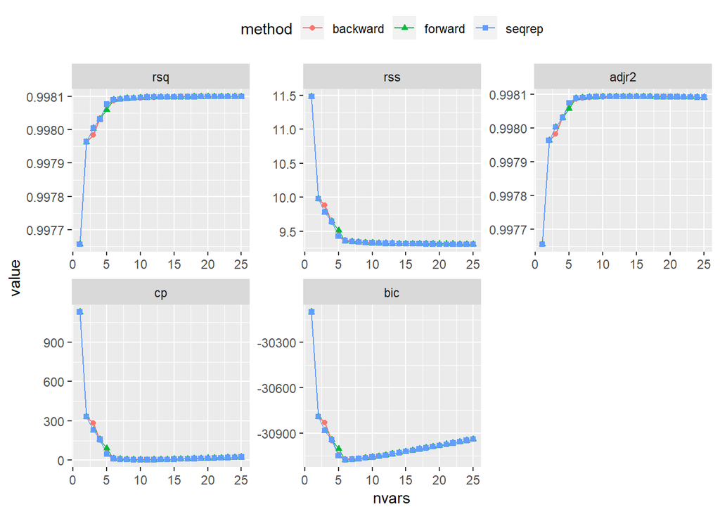

```r
# plot best subset:
ggplot(
    summaryMetrics,
    aes(x=nvars,y=value,shape=method,colour=method)
) + geom_path() + geom_point() + facet_wrap(~metric,scales='free') + theme(legend.position='top')
```

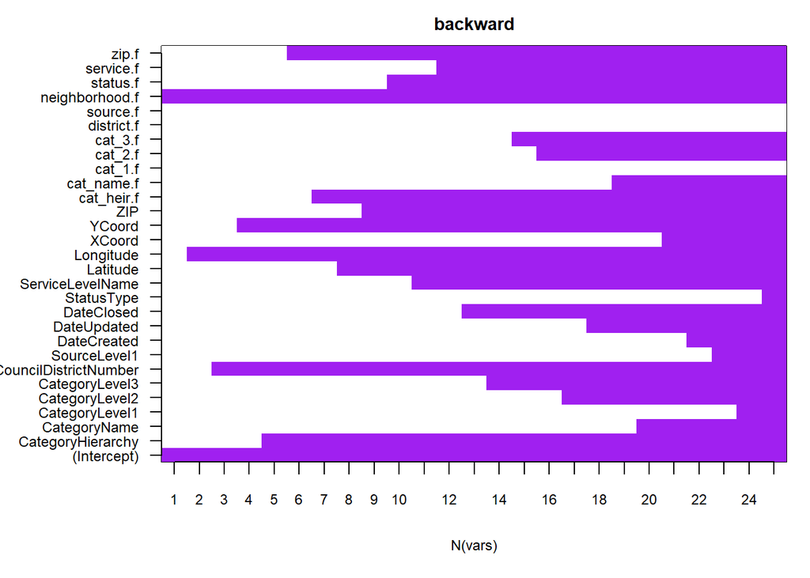

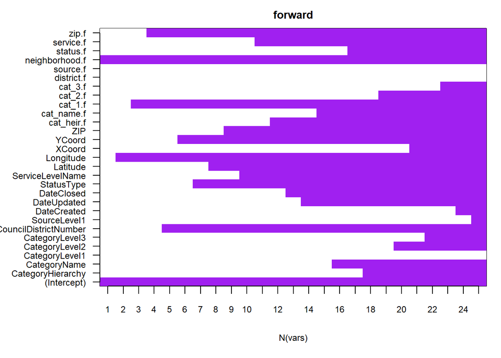

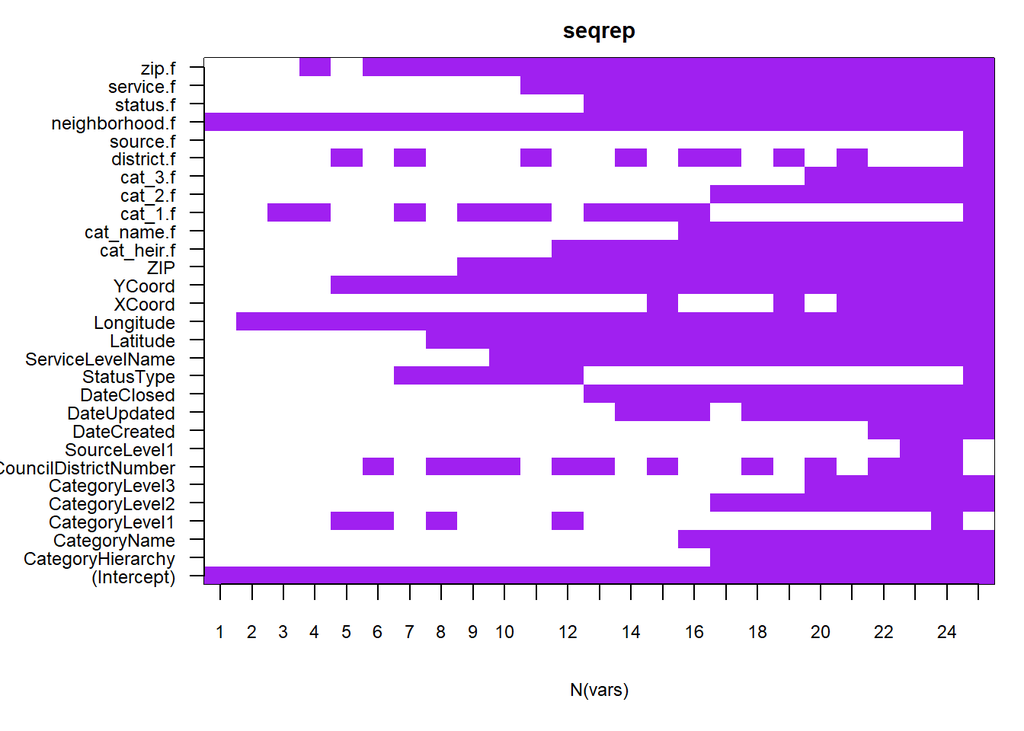

```r
# plot best subset:
old.par <- par(mfrow=c(1,1),ps=9,mar=c(5,7,2,1))
for ( myMthd in names(whichAll) ) {
  image(1:nrow(whichAll[[myMthd]]),
        1:ncol(whichAll[[myMthd]]),
        whichAll[[myMthd]],xlab="N(vars)",ylab="",
        xaxt="n",yaxt="n",breaks=c(-0.5,0.5,1.5),
        col=c("white","purple"),main=myMthd)
  axis(1,1:nrow(whichAll[[myMthd]]),rownames(whichAll[[myMthd]]))
  axis(2,1:ncol(whichAll[[myMthd]]),colnames(whichAll[[myMthd]]),las=2)
}
```

# Recommendations

The objective of this study was to identify trends for developing useful features into the Portal application; as a result the follow recommendations are provided based on results of statistical and spatial analysis:

1. Service Call Clusters - Service calls were grouped into the downtown, Pocket and Natomas neighborhoods; as a result, these areas are recommended as focus areas to organize neighborhoods followed by the other groups observed in the spatial analysis plots.
2. Service Call Categories - Solid waste, trash and dumping-related calls were the majority of calls; as a result, this should be an areas of focus for communities when providing them support of their issues.

# Conclusion

1. Summary statistics revealed that most variables with categorical; neighborhood/location data is of particular interest and would be useful for developing application features.
2. Time/location data will be used for additional analysis (time series/spatial analysis).
3. Categorical variable conversion was not as successful as expected; variables did not translate to good model fit.